# Jack Colpit - Jupyter Notebook Example

[figure not shown]

## Jack Colpitt

#### GEOG 498 Lesson 3

#### Analysis with open source and proprietary APIs

#### Overview

- The project goal is to analyze and produce summaries of traveling acitivities for members of the sales team in a well documented Jupyter Notebook. Since the data needs to be cleaned and organized, we will implement python libraries to iterate the data, find the desired values, and create an interactive mapping visualization through the ArcGIS API for Python. The steps below document the process to achieve the results in a clear reproducible way.
- Python libraries utilized / use case:
  > - GDAL/OGR -> Creating a shapefile from geometries and attributes stored in a csv.
  > - arcgis - ArcGIS API for Python -> Accessing ArcGIS Online to publish the new shapefile and create an interactive map within the notebook.
  > - pandas -> Importing / exporting mutiple csv files, iterating, concatenating, and joining data.
  > - geopandas -> Importing a csv into a dataframe containing shapely point geometries.
  > - os, re, & zipfile -> Working through file expolorer, importing / exporting the desired files, and zipping.

#### Data Preparation

- List of inputs used for the project from which we can derive our summaries.
  > - Employee names
  > - Start / End dates of travel time
  > - Workspace folder designated as 'projectFiles'
  > - Output shapefile
  > - Output CSV files

#### Step 1 - Set workspace folder variable.

```python
projectFiles = r"C:\Users\JColpitt\AdvPython\L3\assignment3_data_March19_3\assignment3_data_March19"
```

#### Step 2 - Define the rest of the input variables.

- 2.1 - Define the employees_csv variable to the employees.csv file for Name and ID information. We only need the file name (not the whole path) since we will be utilizing the os module and the projectFiles workspace for concatenating the full path. ID will be used in the workflow to join location information to the employee names.

```python
employees_csv = 'employees.csv'
```

- 2.2 - The Start and End date variables are used for querying a pandas dataframe to certain time contraints in datetime format. Our query will be set to any dates after 6-26-2016 and any dates before 5-11-2017. Begin the cell below by importing the datetime module.

```python
import datetime

StartDate = datetime.datetime(2016, 6, 26)
EndDate = datetime.datetime(2017, 5, 11)
```

- 2.3 - This list contains the names we are interested in querying for our dataframe later in the workflow (similiar to the datetimes above).

```python
names = ['Jones, Frank', 'Brown, Justine', 'Samulson, Roger']
```

- 2.4 - Create a variable and define a unique file name for the shapefile we will create through the GDAL/OGR API. The file will be published to ArcGIS Online so uniqueness is very important or it will not publish correctly.

```python
outputShpfile = 'ogrShapefile_jhc.shp'
```

```python
output_csv = 'travelLog_.csv'
output_csv_wkt = 'travelLog_WKT.csv'
```

#### Step 2 - Import employees.csv for name and ID information from the variable defined in 2.1.

```python
import os
import pandas as pd

df_employees = pd.read_csv(os.path.join(projectFiles, employees_csv), header=None, names=['Name', 'ID'])
df_employees
```

|  | Name | ID |
| --- | --- | --- |
| 0 | Smith, Richard | 1234421 |
| 1 | Moore, Lisa | 1231233 |
| 2 | Jones, Frank | 2132222 |
| 3 | Brown, Justine | 2132225 |
| 4 | Samulson, Roger | 3981232 |
| 5 | Madison, Margaret | 1876541 |

#### Step 3 - Iterate through the projectFiles workspace to find csv files containing trip information and create a pandas dataframe.

> - 3.1 - Import the re module and use regular expressions for finding csv's named travel_1001 - travel*1075.csv. This regular expression below says "find files that have the characters 'travel*' followed by any integers, followed by file type .csv"

```python
import re
compiledRE = re.compile('(.*travel_).*\\d.*\\.csv$')
```

- 3.2 - Create an empty list to append each row of each csv, we use the variable csvList. Iterate through the workspace by using the os library with the listdir() function, and select files that only match the regular expression.
> - 3.3 - The if statement in the for loop below appends the selected files to the empty list. There is quite a bit happening in the 3rd line of the if statement. We use a line comprehension statement to read each selected csv file which is creating a dataframe with each row, and the pd.concat function wrapped around the pd.read_csv function will create a single dataframe from all 75 individual dataframes.

```python
csvList = [] #create an empty list for each row of each csv
for i in os.listdir(projectFiles): #iterate through the workspace
    match = compiledRE.match(os.path.join(projectFiles, i)) #match correct files
    if match:
        csvList.append(os.path.join(projectFiles, i))
        #create dataframe reading the csv files and concatenating each row to the single frame, parse_dates will configure the 'Start' / 'End' columns as datetime objects
        df_travel = pd.concat([pd.read_csv(f, sep=',', names=['ID', 'Start', 'End', 'Route'], parse_dates=['Start', 'End']) for f in csvList], ignore_index=True)

#print dataframe
df_travel
```

|  | ID | Start | End | Route |
| --- | --- | --- | --- | --- |
| 0 | 2132222 | 2016-01-07 16:00:00 | 2016-01-26 12:00:00 | Cleveland;Bangor;Erie;Philadelphia;New York;Al... |
| 1 | 1234421 | 2016-01-15 13:00:00 | 2016-01-31 17:00:00 | Philadelphia;Portland;Harrisburg;Burlington;Er... |
| 2 | 2132225 | 2016-01-29 12:00:00 | 2016-02-03 15:00:00 | Bangor;Cleveland;Augusta |
| 3 | 2132225 | 2016-02-10 07:00:00 | 2016-02-22 22:00:00 | Altoona;Augusta;Altoona;Bangor;Augusta;Columbus |
| 4 | 2132222 | 2016-02-19 14:00:00 | 2016-02-25 13:00:00 | Boston;Philadelphia |
| ... | ... | ... | ... | ... |
| 70 | 3981232 | 2017-12-15 07:00:00 | 2017-12-28 15:00:00 | Harrisburg;New York;Altoona;Philadelphia;Washi... |
| 71 | 2132222 | 2017-12-23 10:00:00 | 2018-01-10 20:00:00 | Altoona;Scranton;Columbus;Syracuse;Pittsburgh;... |
| 72 | 3981232 | 2017-12-29 17:00:00 | 2018-01-17 11:00:00 | Syracuse;Augusta;Burlington;Syracuse;Pittsburg... |
| 73 | 1231233 | 2018-01-11 07:00:00 | 2018-01-28 19:00:00 | New York;Erie;Scranton;New York;Columbus;Bosto... |
| 74 | 1234421 | 2018-01-08 15:00:00 | 2018-01-29 18:00:00 | Syracuse;Burlington;Augusta;Altoona;Albany;Por... |

75 rows × 4 columns

#### Step 4 - Confirm the 'Start' and 'End' columns are datetime objects.

```python
df_travel.dtypes
```

```
ID                int64
Start    datetime64[ns]
End      datetime64[ns]
Route            object
dtype: object
```

#### Step 5 - Join dataframes df_names & df_travel on the 'ID' field with the pd.merge() function.

```python
df_join = df_employees.merge(df_travel, left_on='ID', right_on='ID')
df_join
```

|  | Name | ID | Start | End | Route |
| --- | --- | --- | --- | --- | --- |
| 0 | Smith, Richard | 1234421 | 2016-01-15 13:00:00 | 2016-01-31 17:00:00 | Philadelphia;Portland;Harrisburg;Burlington;Er... |
| 1 | Smith, Richard | 1234421 | 2016-04-09 06:00:00 | 2016-04-16 22:00:00 | Augusta;New York;Columbus;Syracuse;Albany |
| 2 | Smith, Richard | 1234421 | 2016-04-22 15:00:00 | 2016-05-02 20:00:00 | Columbus;Burlington;Augusta;Syracuse;Augusta;P... |
| 3 | Smith, Richard | 1234421 | 2016-05-09 06:00:00 | 2016-05-18 22:00:00 | Boston;Albany;Harrisburg;Erie |
| 4 | Smith, Richard | 1234421 | 2016-05-19 08:00:00 | 2016-05-25 16:00:00 | Portland;Washington |
| ... | ... | ... | ... | ... | ... |
| 70 | Madison, Margaret | 1876541 | 2017-03-05 11:00:00 | 2017-03-17 14:00:00 | Altoona;Columbus;Philadelphia;Augusta;Bangor;B... |
| 71 | Madison, Margaret | 1876541 | 2017-04-11 15:00:00 | 2017-04-25 18:00:00 | Portland;Burlington;Cleveland;Altoona;Scranton... |
| 72 | Madison, Margaret | 1876541 | 2017-05-20 15:00:00 | 2017-06-06 17:00:00 | Albany;Boston;Pittsburgh;Cleveland;New York;Ph... |
| 73 | Madison, Margaret | 1876541 | 2018-01-05 10:00:00 | 2018-01-16 13:00:00 | Philadelphia;Burlington;Washington;Erie |
| 74 | Madison, Margaret | 1876541 | 2017-12-03 08:00:00 | 2017-12-21 21:00:00 | Bangor;New York;Burlington;Bangor;Erie;Portlan... |

75 rows × 5 columns

#### Step 6 - Filter the dataframe to only show trips from employees in the 'names' input (defined in 2.3) and in between the 'StartDate' & 'EndDate' defined in 2.2.

> - 6.1 - Once data is filtered with the .isin() function and the datetime variables. Use the .reset_index() to index the rows starting from 0. Make sure to use the parameter drop=True to eliminate the added index colunmn that comes default with reset_index.

```python
df_filter = (df_join [ df_join.Name.isin(names)] [(df_join.iloc[:,2] > StartDate) & (df_join.iloc[:,3] < EndDate)])
df_filtered = df_filter.reset_index(drop=True)
df_filtered
```

[output not shown]

#### Step 7.1 - Add the 'Duration' column containing time delta values from 'End' - 'Start'.

```python
df_filtered['Duration'] = (df_filtered['End'] - df_filtered['Start']).dt.days
df_filterDuration = df_filtered.copy() #copy the dataframe with the newly added column
df_filterDuration
```

|  | Name | ID | Start | End | Route | Duration |
| --- | --- | --- | --- | --- | --- | --- |
| 0 | Jones, Frank | 2132222 | 2016-07-10 18:00:00 | 2016-07-15 18:00:00 | Harrisburg;Augusta | 5 |
| 1 | Jones, Frank | 2132222 | 2017-01-18 12:00:00 | 2017-01-28 19:00:00 | Philadelphia;Boston;Altoona;Harrisburg;Scranton | 10 |
| 2 | Jones, Frank | 2132222 | 2017-03-16 17:00:00 | 2017-04-02 18:00:00 | Augusta;New York;Scranton;Columbus;Washington;... | 17 |
| 3 | Brown, Justine | 2132225 | 2016-08-02 13:00:00 | 2016-08-14 16:00:00 | Albany;Scranton;Philadelphia;Scranton;Augusta | 12 |
| 4 | Brown, Justine | 2132225 | 2016-11-04 17:00:00 | 2016-11-23 20:00:00 | New York;Portland;Boston;Portland;Washington;P... | 19 |
| 5 | Brown, Justine | 2132225 | 2016-11-30 16:00:00 | 2016-12-06 14:00:00 | Pittsburgh;Syracuse | 5 |
| 6 | Brown, Justine | 2132225 | 2016-12-12 12:00:00 | 2016-12-21 19:00:00 | Columbus;Boston;Pittsburgh | 9 |
| 7 | Brown, Justine | 2132225 | 2017-01-07 11:00:00 | 2017-01-19 17:00:00 | Harrisburg;Portland;Boston;Syracuse;Albany | 12 |
| 8 | Brown, Justine | 2132225 | 2017-03-27 06:00:00 | 2017-04-13 14:00:00 | Portland;Boston;Bangor;Washington;Harrisburg;P... | 17 |
| 9 | Samulson, Roger | 3981232 | 2016-07-24 17:00:00 | 2016-08-03 12:00:00 | Erie;Syracuse;Philadelphia;Bangor;Scranton | 9 |
| 10 | Samulson, Roger | 3981232 | 2016-10-15 07:00:00 | 2016-10-22 17:00:00 | Boston;Syracuse;Portland;Altoona | 7 |
| 11 | Samulson, Roger | 3981232 | 2016-12-25 17:00:00 | 2017-01-12 17:00:00 | Boston;Cleveland;Pittsburgh;Philadelphia;Harri... | 18 |
| 12 | Samulson, Roger | 3981232 | 2017-02-10 07:00:00 | 2017-02-17 19:00:00 | Portland;Augusta;Burlington;Philadelphia | 7 |
| 13 | Samulson, Roger | 3981232 | 2017-02-24 06:00:00 | 2017-03-11 20:00:00 | New York;Augusta;Pittsburgh;Cleveland;Altoona | 15 |

#### 7.2 - Sort 'Name' and 'Duration' in ascending order with pd.sort_values().

```python
df_sorted = df_filterDuration.sort_values(['Name', 'Duration'], ascending=[True, True], ignore_index=True)
df_sorted
```

|  | Name | ID | Start | End | Route | Duration |
| --- | --- | --- | --- | --- | --- | --- |
| 0 | Brown, Justine | 2132225 | 2016-11-30 16:00:00 | 2016-12-06 14:00:00 | Pittsburgh;Syracuse | 5 |
| 1 | Brown, Justine | 2132225 | 2016-12-12 12:00:00 | 2016-12-21 19:00:00 | Columbus;Boston;Pittsburgh | 9 |
| 2 | Brown, Justine | 2132225 | 2016-08-02 13:00:00 | 2016-08-14 16:00:00 | Albany;Scranton;Philadelphia;Scranton;Augusta | 12 |
| 3 | Brown, Justine | 2132225 | 2017-01-07 11:00:00 | 2017-01-19 17:00:00 | Harrisburg;Portland;Boston;Syracuse;Albany | 12 |
| 4 | Brown, Justine | 2132225 | 2017-03-27 06:00:00 | 2017-04-13 14:00:00 | Portland;Boston;Bangor;Washington;Harrisburg;P... | 17 |
| 5 | Brown, Justine | 2132225 | 2016-11-04 17:00:00 | 2016-11-23 20:00:00 | New York;Portland;Boston;Portland;Washington;P... | 19 |
| 6 | Jones, Frank | 2132222 | 2016-07-10 18:00:00 | 2016-07-15 18:00:00 | Harrisburg;Augusta | 5 |
| 7 | Jones, Frank | 2132222 | 2017-01-18 12:00:00 | 2017-01-28 19:00:00 | Philadelphia;Boston;Altoona;Harrisburg;Scranton | 10 |
| 8 | Jones, Frank | 2132222 | 2017-03-16 17:00:00 | 2017-04-02 18:00:00 | Augusta;New York;Scranton;Columbus;Washington;... | 17 |
| 9 | Samulson, Roger | 3981232 | 2016-10-15 07:00:00 | 2016-10-22 17:00:00 | Boston;Syracuse;Portland;Altoona | 7 |
| 10 | Samulson, Roger | 3981232 | 2017-02-10 07:00:00 | 2017-02-17 19:00:00 | Portland;Augusta;Burlington;Philadelphia | 7 |
| 11 | Samulson, Roger | 3981232 | 2016-07-24 17:00:00 | 2016-08-03 12:00:00 | Erie;Syracuse;Philadelphia;Bangor;Scranton | 9 |
| 12 | Samulson, Roger | 3981232 | 2017-02-24 06:00:00 | 2017-03-11 20:00:00 | New York;Augusta;Pittsburgh;Cleveland;Altoona | 15 |
| 13 | Samulson, Roger | 3981232 | 2016-12-25 17:00:00 | 2017-01-12 17:00:00 | Boston;Cleveland;Pittsburgh;Philadelphia;Harri... | 18 |

#### 7.3 - Sort columns by 'Name', 'ID', 'Duration', 'Start', 'End', and 'Route'.

```python
df_reordered = df_sorted[['Name', 'ID', 'Duration', 'Start', 'End', 'Route']]
dfReordered = df_reordered.copy()
dfReordered
```

|  | Name | ID | Duration | Start | End | Route |
| --- | --- | --- | --- | --- | --- | --- |
| 0 | Brown, Justine | 2132225 | 5 | 2016-11-30 16:00:00 | 2016-12-06 14:00:00 | Pittsburgh;Syracuse |
| 1 | Brown, Justine | 2132225 | 9 | 2016-12-12 12:00:00 | 2016-12-21 19:00:00 | Columbus;Boston;Pittsburgh |
| 2 | Brown, Justine | 2132225 | 12 | 2016-08-02 13:00:00 | 2016-08-14 16:00:00 | Albany;Scranton;Philadelphia;Scranton;Augusta |
| 3 | Brown, Justine | 2132225 | 12 | 2017-01-07 11:00:00 | 2017-01-19 17:00:00 | Harrisburg;Portland;Boston;Syracuse;Albany |
| 4 | Brown, Justine | 2132225 | 17 | 2017-03-27 06:00:00 | 2017-04-13 14:00:00 | Portland;Boston;Bangor;Washington;Harrisburg;P... |
| 5 | Brown, Justine | 2132225 | 19 | 2016-11-04 17:00:00 | 2016-11-23 20:00:00 | New York;Portland;Boston;Portland;Washington;P... |
| 6 | Jones, Frank | 2132222 | 5 | 2016-07-10 18:00:00 | 2016-07-15 18:00:00 | Harrisburg;Augusta |
| 7 | Jones, Frank | 2132222 | 10 | 2017-01-18 12:00:00 | 2017-01-28 19:00:00 | Philadelphia;Boston;Altoona;Harrisburg;Scranton |
| 8 | Jones, Frank | 2132222 | 17 | 2017-03-16 17:00:00 | 2017-04-02 18:00:00 | Augusta;New York;Scranton;Columbus;Washington;... |
| 9 | Samulson, Roger | 3981232 | 7 | 2016-10-15 07:00:00 | 2016-10-22 17:00:00 | Boston;Syracuse;Portland;Altoona |
| 10 | Samulson, Roger | 3981232 | 7 | 2017-02-10 07:00:00 | 2017-02-17 19:00:00 | Portland;Augusta;Burlington;Philadelphia |
| 11 | Samulson, Roger | 3981232 | 9 | 2016-07-24 17:00:00 | 2016-08-03 12:00:00 | Erie;Syracuse;Philadelphia;Bangor;Scranton |
| 12 | Samulson, Roger | 3981232 | 15 | 2017-02-24 06:00:00 | 2017-03-11 20:00:00 | New York;Augusta;Pittsburgh;Cleveland;Altoona |
| 13 | Samulson, Roger | 3981232 | 18 | 2016-12-25 17:00:00 | 2017-01-12 17:00:00 | Boston;Cleveland;Pittsburgh;Philadelphia;Harri... |

#### Step 8 - Output the dataframe to a csv file in the designated workspace 'projectFiles' with the output variable set in 2.5.

```python
dfReordered.to_csv(os.path.join(projectFiles, output_csv))
```

#### Step 9 - Import the geopandas module and read in the ne_cities.shp to a dataframe where we can access the shapely geometry points in the geometry column.

```python
import geopandas as gpd

NECitiesShp = gpd.read_file(os.path.join(projectFiles, 'ne_cities.shp'))
NECitiesShp.head()
```

|  | OBJECTID | UIDENT | POPCLASS | NAME | CAPITAL | STATEABB | COUNTRY | geometry |
| --- | --- | --- | --- | --- | --- | --- | --- | --- |
| 0 | 15 | 62507.0 | 2.0 | Bangor | -1.0 | US-ME | USA | POINT (-68.77619 44.81189) |
| 1 | 20 | 64707.0 | 2.0 | Waterville | -1.0 | US-ME | USA | POINT (-69.62073 44.53724) |
| 2 | 23 | 65607.0 | 2.0 | Augusta | 1.0 | US-ME | USA | POINT (-69.78141 44.32166) |
| 3 | 26 | 66707.0 | 2.0 | Berlin | -1.0 | US-NH | USA | POINT (-71.19324 44.46470) |
| 4 | 29 | 67407.0 | 2.0 | Lewiston | -1.0 | US-ME | USA | POINT (-70.19406 44.10972) |

#### Step 10 - To create a linestring geometry for the traveling sales team we use the code below to join the shapely geometry values from the ne_cities.shp file to the cities in the 'dfReordered' dataframe.

> - The value is put into a string variable 'wkt' which stands for well known text (WKT). A useful format in the GDAL/OGR API for creating geometries.

```python
wkt = [ 'LineString (' + ','.join([ '{0} {1}'.format(NECitiesShp[NECitiesShp.NAME == city].geometry.x.iloc[0], NECitiesShp[NECitiesShp.NAME == city].geometry.y.iloc[0]) for city in r.split(';') ])+')' for r in dfReordered.Route]
```

#### Step 11 - The values of the 'wkt' are now brought into our original 'dfReordered' dataframe as a new column and joined to their matching rows.

> - For organization and formatting, we drop uneccessary values, and export the dataframe to a csv where can utilize the columns and rows for fields in a new shapefile created with the GDAL/OGR API.
- 11.1 - Add the new column with the 'wkt' linestrings

```python
dfReordered['WKT'] = wkt
dfReordered
```

|  | Name | ID | Duration | Start | End | Route | WKT |
| --- | --- | --- | --- | --- | --- | --- | --- |
| 0 | Brown, Justine | 2132225 | 5 | 2016-11-30 16:00:00 | 2016-12-06 14:00:00 | Pittsburgh;Syracuse | LineString (-79.91439598338775 40.447399277754... |
| 1 | Brown, Justine | 2132225 | 9 | 2016-12-12 12:00:00 | 2016-12-21 19:00:00 | Columbus;Boston;Pittsburgh | LineString (-82.98182532058195 39.972384950705... |
| 2 | Brown, Justine | 2132225 | 12 | 2016-08-02 13:00:00 | 2016-08-14 16:00:00 | Albany;Scranton;Philadelphia;Scranton;Augusta | LineString (-73.78191599152962 42.674015577157... |
| 3 | Brown, Justine | 2132225 | 12 | 2017-01-07 11:00:00 | 2017-01-19 17:00:00 | Harrisburg;Portland;Boston;Syracuse;Albany | LineString (-76.82629734234831 40.266819768117... |
| 4 | Brown, Justine | 2132225 | 17 | 2017-03-27 06:00:00 | 2017-04-13 14:00:00 | Portland;Boston;Bangor;Washington;Harrisburg;P... | LineString (-70.27758484016806 43.698554552950... |
| 5 | Brown, Justine | 2132225 | 19 | 2016-11-04 17:00:00 | 2016-11-23 20:00:00 | New York;Portland;Boston;Portland;Washington;P... | LineString (-73.95605368612854 40.648657910034... |
| 6 | Jones, Frank | 2132222 | 5 | 2016-07-10 18:00:00 | 2016-07-15 18:00:00 | Harrisburg;Augusta | LineString (-76.82629734234831 40.266819768117... |
| 7 | Jones, Frank | 2132222 | 10 | 2017-01-18 12:00:00 | 2017-01-28 19:00:00 | Philadelphia;Boston;Altoona;Harrisburg;Scranton | LineString (-75.16727846213115 39.941228213611... |
| 8 | Jones, Frank | 2132222 | 17 | 2017-03-16 17:00:00 | 2017-04-02 18:00:00 | Augusta;New York;Scranton;Columbus;Washington;... | LineString (-69.78141264717578 44.321655641294... |
| 9 | Samulson, Roger | 3981232 | 7 | 2016-10-15 07:00:00 | 2016-10-22 17:00:00 | Boston;Syracuse;Portland;Altoona | LineString (-71.08008355451227 42.362833160122... |
| 10 | Samulson, Roger | 3981232 | 7 | 2017-02-10 07:00:00 | 2017-02-17 19:00:00 | Portland;Augusta;Burlington;Philadelphia | LineString (-70.27758484016806 43.698554552950... |
| 11 | Samulson, Roger | 3981232 | 9 | 2016-07-24 17:00:00 | 2016-08-03 12:00:00 | Erie;Syracuse;Philadelphia;Bangor;Scranton | LineString (-80.06309969219689 42.104663488929... |
| 12 | Samulson, Roger | 3981232 | 15 | 2017-02-24 06:00:00 | 2017-03-11 20:00:00 | New York;Augusta;Pittsburgh;Cleveland;Altoona | LineString (-73.95605368612854 40.648657910034... |
| 13 | Samulson, Roger | 3981232 | 18 | 2016-12-25 17:00:00 | 2017-01-12 17:00:00 | Boston;Cleveland;Pittsburgh;Philadelphia;Harri... | LineString (-71.08008355451227 42.362833160122... |

- 11.2 - Drop uneccessary columns

```python
dfReordered.drop(['ID','Start', 'End'], axis=1, inplace=True)
dfReordered
```

|  | Name | Duration | Route | WKT |
| --- | --- | --- | --- | --- |
| 0 | Brown, Justine | 5 | Pittsburgh;Syracuse | LineString (-79.91439598338775 40.447399277754... |
| 1 | Brown, Justine | 9 | Columbus;Boston;Pittsburgh | LineString (-82.98182532058195 39.972384950705... |
| 2 | Brown, Justine | 12 | Albany;Scranton;Philadelphia;Scranton;Augusta | LineString (-73.78191599152962 42.674015577157... |
| 3 | Brown, Justine | 12 | Harrisburg;Portland;Boston;Syracuse;Albany | LineString (-76.82629734234831 40.266819768117... |
| 4 | Brown, Justine | 17 | Portland;Boston;Bangor;Washington;Harrisburg;P... | LineString (-70.27758484016806 43.698554552950... |
| 5 | Brown, Justine | 19 | New York;Portland;Boston;Portland;Washington;P... | LineString (-73.95605368612854 40.648657910034... |
| 6 | Jones, Frank | 5 | Harrisburg;Augusta | LineString (-76.82629734234831 40.266819768117... |
| 7 | Jones, Frank | 10 | Philadelphia;Boston;Altoona;Harrisburg;Scranton | LineString (-75.16727846213115 39.941228213611... |
| 8 | Jones, Frank | 17 | Augusta;New York;Scranton;Columbus;Washington;... | LineString (-69.78141264717578 44.321655641294... |
| 9 | Samulson, Roger | 7 | Boston;Syracuse;Portland;Altoona | LineString (-71.08008355451227 42.362833160122... |
| 10 | Samulson, Roger | 7 | Portland;Augusta;Burlington;Philadelphia | LineString (-70.27758484016806 43.698554552950... |
| 11 | Samulson, Roger | 9 | Erie;Syracuse;Philadelphia;Bangor;Scranton | LineString (-80.06309969219689 42.104663488929... |
| 12 | Samulson, Roger | 15 | New York;Augusta;Pittsburgh;Cleveland;Altoona | LineString (-73.95605368612854 40.648657910034... |
| 13 | Samulson, Roger | 18 | Boston;Cleveland;Pittsburgh;Philadelphia;Harri... | LineString (-71.08008355451227 42.362833160122... |

- 11.3 - Create a copy and reorder the columns to match project formatting

```python
df_WKT = dfReordered.copy()
df_WKT = df_WKT[['Name', 'Route', 'Duration', 'WKT']]
```

- 11.4 - Print the new dataframe with the desired values discussed in the beginning of the workflow overview.

```python
df_WKT
```

|  | Name | Route | Duration | WKT |
| --- | --- | --- | --- | --- |
| 0 | Brown, Justine | Pittsburgh;Syracuse | 5 | LineString (-79.91439598338775 40.447399277754... |
| 1 | Brown, Justine | Columbus;Boston;Pittsburgh | 9 | LineString (-82.98182532058195 39.972384950705... |
| 2 | Brown, Justine | Albany;Scranton;Philadelphia;Scranton;Augusta | 12 | LineString (-73.78191599152962 42.674015577157... |
| 3 | Brown, Justine | Harrisburg;Portland;Boston;Syracuse;Albany | 12 | LineString (-76.82629734234831 40.266819768117... |
| 4 | Brown, Justine | Portland;Boston;Bangor;Washington;Harrisburg;P... | 17 | LineString (-70.27758484016806 43.698554552950... |
| 5 | Brown, Justine | New York;Portland;Boston;Portland;Washington;P... | 19 | LineString (-73.95605368612854 40.648657910034... |
| 6 | Jones, Frank | Harrisburg;Augusta | 5 | LineString (-76.82629734234831 40.266819768117... |
| 7 | Jones, Frank | Philadelphia;Boston;Altoona;Harrisburg;Scranton | 10 | LineString (-75.16727846213115 39.941228213611... |
| 8 | Jones, Frank | Augusta;New York;Scranton;Columbus;Washington;... | 17 | LineString (-69.78141264717578 44.321655641294... |
| 9 | Samulson, Roger | Boston;Syracuse;Portland;Altoona | 7 | LineString (-71.08008355451227 42.362833160122... |
| 10 | Samulson, Roger | Portland;Augusta;Burlington;Philadelphia | 7 | LineString (-70.27758484016806 43.698554552950... |
| 11 | Samulson, Roger | Erie;Syracuse;Philadelphia;Bangor;Scranton | 9 | LineString (-80.06309969219689 42.104663488929... |
| 12 | Samulson, Roger | New York;Augusta;Pittsburgh;Cleveland;Altoona | 15 | LineString (-73.95605368612854 40.648657910034... |
| 13 | Samulson, Roger | Boston;Cleveland;Pittsburgh;Philadelphia;Harri... | 18 | LineString (-71.08008355451227 42.362833160122... |

- 11.5 - Let showcase another power of the notebook and Pandas API with the ability to leverage data visualization.
> - Plot the names of the employees on the x axis, and the duration of their travel on the y axis.

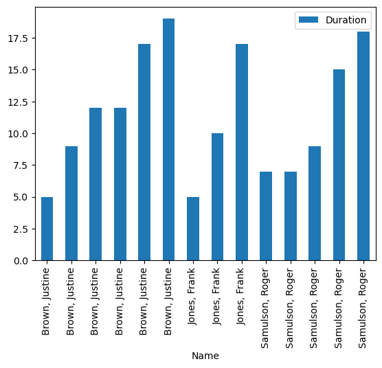

```python
chart = df_WKT.plot.bar(x='Name', y='Duration')
```

- 11.6 - Export to csv with the second variable created in 2.5.

```python
df_WKT.to_csv(os.path.join(projectFiles, output_csv_wkt))
```

#### Step 12 - Use the GDAL/OGR API for creating a shapefile from the 'travelLog_WKT.csv'

- 12.1 - Import ogr, and osr libraries

```python
from osgeo import osr
from osgeo import ogr
```

```python
drv = ogr.GetDriverByName('CSV')
dataSet = drv.Open(os.path.join(projectFiles, 'travelLog_WKT.csv'))
```

- 12.3 - From dataSet.GetLayer() and layer.GetLayerDefn() we can access the fields and attributes of the csv and assign them to the new shapefile created below.

```python
layer = dataSet.GetLayer(0)
layerDefinition = layer.GetLayerDefn()
```

- 12.4 - The steps below in the next cell go through the process of creating a new shapefile (outfile), creating a new layer in the shapefile (outlayer), and adding new fields to the output layer.

```python
drv = ogr.GetDriverByName('ESRI Shapefile')
sr = osr.SpatialReference()
sr.ImportFromEPSG(4326)
outfile = drv.CreateDataSource(os.path.join(projectFiles, outputShpfile))
outlayer = outfile.CreateLayer(outputShpfile.rstrip('.shp'), geom_type=ogr.wkbLineString, srs=sr)

nameField = ogr.FieldDefn('Name', ogr.OFTString)
outlayer.CreateField(nameField)
nameField = ogr.FieldDefn('Route', ogr.OFTString)
outlayer.CreateField(nameField)
nameField = ogr.FieldDefn('Duration', ogr.OFTInteger)
outlayer.CreateField(nameField)

featureDefn = outlayer.GetLayerDefn()
```

- 12.5 - In the for loop below we will create the new geometry from the well known text column, and also assign values to the fields in the shapefile (all values are derived from the csv we assigned to the dataSet variable.

```python
for feature in layer:

    outFeature = ogr.Feature(featureDefn)
    outFeature.SetGeometry(ogr.CreateGeometryFromWkt(feature.GetField('WKT')))

    outFeature.SetField('Name', feature.GetField('Name'))
    outFeature.SetField('Route', feature.GetField('Route'))
    outFeature.SetField('Duration', feature.GetField('Duration'))
    outlayer.CreateFeature(outFeature)
    outFeature = None

layer.ResetReading()
outfile = None
```

#### Step 13 - Zip up the shapefile to publish to ArcGIS Online.

```python
import zipfile
# function to create zipped shapefile for a given filename without extension
def zipShapefile(name):
    compiledRE = re.compile(name+'(?!.zip)\\....$')
    with zipfile.ZipFile( os.path.join(projectFiles, name + '.zip'), 'w', zipfile.ZIP_DEFLATED) as zf:  # create zipfile
        for file in os.listdir(projectFiles):                                                           # go through files in workspace
            if compiledRE.match(file):                                                               # test whether file is part of the shapefile to be zipped
                zf.write(os.path.join(projectFiles,file),file,zipfile.ZIP_DEFLATED)                     # add file to zipfile

# create zipped version of observation shapefile\n",
zipShapefile( os.path.splitext(outputShpfile)[0] )
```

#### Step 14 - Import the ArcGIS API for Python modules, log in to AGOL, and validate credentials.

```python
import arcgis
from arcgis.gis import GIS
from IPython.display import display
from arcgis.features import *
from arcgis.geometry import *
from arcgis.mapping import *
```

- 14.1 - Log into AGOL

```python
gis = GIS('https://pennstate.maps.arcgis.com', client_id='########')
gis
```

- 14.2 - Validate credentials and confirm log in was a success.

[figure not shown]

[**Jack Colpitt**](https://pennstate.maps.arcgis.com/home/user.html?user=jhc5508_pennstate)  
**Bio**: None  
**First Name**: Jack  
**Last Name**: Colpitt  
**Username**: jhc5508_pennstate  
**Joined**: September 26, 2022

```python
gis.users.me
```

#### Step 15 - Publish shapefile & Print out a list of Feature Services with AGOL user name for indexing purposes.

```python
ogrShpFile = gis.content.add({'type':'Shapefile'}, os.path.join(projectFiles, outputShpfile.rstrip('.shp') + '.zip'))
ogrShpFileFS = ogrShpFile.publish()
```

- 15.1 - Use the content manager class of the gis module to see feature services that are available. We will also use this list an index for adding features to our interactive map.

```python
JhcContent = gis.content.search(query='owner:jhc5508_pennstate', item_type='Feature Service')
JhcContent
```

[output not shown]

- 15.2 - Use the content list to create a dataframe for organizational purposes.

```python
df_JhcContent = pd.DataFrame(JhcContent, columns=['id', 'owner', 'title', 'type'])
df_JhcContent
```

|  | id | owner | title | type |
| --- | --- | --- | --- | --- |
| 0 | 7fde4e57bdf748ee9b0d2f3c32fb5f76 | jhc5508_pennstate | ne_cities_jackhc | Feature Service |
| 1 | 241041adc2da4ea3bfe7e3e42961647e | jhc5508_pennstate | ogrShapefile_jhc | Feature Service |
| 2 | 10a1ccc05f8e4de49454cd6c3dba28f2 | jhc5508_pennstate | dcnr_apptrail_2003_jhc | Feature Service |

#### Step 16 - Set a variable for the map name and use the map & add_layer functions from the gis module to begin adding content to the map with the ArcGIS API for Python.

```python
NE_Map = gis.map(JhcContent[2])
NE_Map.add_layer(JhcContent[2], {"renderer":"ClassedColorRenderer",
                           "field_name": "Duration", })
NE_Map.add_layer(JhcContent[1], {})
NE_Map.basemap = 'streets-night-vector'

NE_Map
```

```
MapView(layout=Layout(height='400px', width='100%'))
```

[figure not shown]

- 16.1 - With the large list of uneccessary cities in our map, lets run an intersect overlay to only show the cities that were visited by the list of employees in our published shapefile. We will need to bring in another module shown below in the next cell.

```python
from arcgis.features.manage_data import overlay_layers
citiesFromTrips = overlay_layers(NE_Map.layers[0], NE_Map.layers[1], overlay_type='Intersect')
```

- 16.2 - Add the new citiesFromTrips layer to the map.

```python
NE_Map.add_layer(citiesFromTrips)
```

- 16.3 - Now remove the ne_cities_jackhc shapefile from the map.

```python
NE_Map.remove_layers(layers=[JhcContent[0]])
```

```
True
```

#### Step 17 - Now that we've seen a way to add the visited cities to the map through ESRI, let's take a look at accomplishing the same goals but with the GDAL/OGR API.

> - 17.1 First thing is to adapt the code from step 10 to create a multipoint representation of well known text. The GDAL/OGR library can read the WKT into a new shapefile that will hold a series of points in each row of the attribute table.

```python
wkt_multi = [ 'MULTIPOINT (' + ', '.join([ '{0} {1}'.format(NECitiesShp[NECitiesShp.NAME == city].geometry.x.iloc[0], NECitiesShp[NECitiesShp.NAME == city].geometry.y.iloc[0]) for city in r.split(';') ])+')' for r in dfReordered.Route]
```

- 17.2 - Let's have a look at the simple for loop to see the adapted output.

```python
for i in wkt_multi:
    print(i)
```

```
MULTIPOINT (-79.91439598338775 40.44739927775465, -76.11541933583351 43.069102679844946)
MULTIPOINT (-82.98182532058195 39.97238495070508, -71.08008355451227 42.36283316012242, -79.91439598338775 40.44739927775465)
MULTIPOINT (-73.78191599152962 42.67401557715732, -75.6846942543362 41.42554577072093, -75.16727846213115 39.94122821361134, -75.6846942543362 41.42554577072093, -69.78141264717578 44.32165564129497)
MULTIPOINT (-76.82629734234831 40.266819768117955, -70.27758484016806 43.69855455295044, -71.08008355451227 42.36283316012242, -76.11541933583351 43.069102679844946, -73.78191599152962 42.67401557715732)
MULTIPOINT (-70.27758484016806 43.69855455295044, -71.08008355451227 42.36283316012242, -68.77619355059176 44.811894649718454, -76.97076581628926 38.95143772776908, -76.82629734234831 40.266819768117955, -79.91439598338775 40.44739927775465)
MULTIPOINT (-73.95605368612854 40.64865791003467, -70.27758484016806 43.69855455295044, -71.08008355451227 42.36283316012242, -70.27758484016806 43.69855455295044, -76.97076581628926 38.95143772776908, -79.91439598338775 40.44739927775465, -76.11541933583351 43.069102679844946, -75.6846942543362 41.…
MULTIPOINT (-76.82629734234831 40.266819768117955, -69.78141264717578 44.32165564129497)
MULTIPOINT (-75.16727846213115 39.94122821361134, -71.08008355451227 42.36283316012242, -78.40098738336093 40.52565171805253, -76.82629734234831 40.266819768117955, -75.6846942543362 41.42554577072093)
MULTIPOINT (-69.78141264717578 44.32165564129497, -73.95605368612854 40.64865791003467, -75.6846942543362 41.42554577072093, -82.98182532058195 39.97238495070508, -76.97076581628926 38.95143772776908, -69.78141264717578 44.32165564129497, -68.77619355059176 44.811894649718454)
MULTIPOINT (-71.08008355451227 42.36283316012242, -76.11541933583351 43.069102679844946, -70.27758484016806 43.69855455295044, -78.40098738336093 40.52565171805253)
MULTIPOINT (-70.27758484016806 43.69855455295044, -69.78141264717578 44.32165564129497, -73.2096932475452 44.50329722688571, -75.16727846213115 39.94122821361134)
MULTIPOINT (-80.06309969219689 42.10466348892903, -76.11541933583351 43.069102679844946, -75.16727846213115 39.94122821361134, -68.77619355059176 44.811894649718454, -75.6846942543362 41.42554577072093)
MULTIPOINT (-73.95605368612854 40.64865791003467, -69.78141264717578 44.32165564129497, -79.91439598338775 40.44739927775465, -81.57637997965219 41.492262952473425, -78.40098738336093 40.52565171805253)
MULTIPOINT (-71.08008355451227 42.36283316012242, -81.57637997965219 41.492262952473425, -79.91439598338775 40.44739927775465, -75.16727846213115 39.94122821361134, -76.82629734234831 40.266819768117955, -73.78191599152962 42.67401557715732, -70.27758484016806 43.69855455295044, -76.82629734234831 4…
```

#### Step 18 - The steps will begin to look familiar as we work through the process of creating a dataframe, ouputting to a csv, and reading in the csv to a shapefile.

> - 18.1 - Bring in the dfReordered dataframe from step 11.2 to replace the original column 'WKT' with 'WKT_PT' holding our new multipoint values by dropping and adding.

```python
df_WKT_p = dfReordered.copy()
df_WKT_p.drop(['WKT'], axis=1, inplace=True)
df_WKT_p['WKT_PT'] = wkt_multi
df_WKT_p
```

|  | Name | Duration | Route | WKT_PT |
| --- | --- | --- | --- | --- |
| 0 | Brown, Justine | 5 | Pittsburgh;Syracuse | MULTIPOINT (-79.91439598338775 40.447399277754... |
| 1 | Brown, Justine | 9 | Columbus;Boston;Pittsburgh | MULTIPOINT (-82.98182532058195 39.972384950705... |
| 2 | Brown, Justine | 12 | Albany;Scranton;Philadelphia;Scranton;Augusta | MULTIPOINT (-73.78191599152962 42.674015577157... |
| 3 | Brown, Justine | 12 | Harrisburg;Portland;Boston;Syracuse;Albany | MULTIPOINT (-76.82629734234831 40.266819768117... |
| 4 | Brown, Justine | 17 | Portland;Boston;Bangor;Washington;Harrisburg;P... | MULTIPOINT (-70.27758484016806 43.698554552950... |
| 5 | Brown, Justine | 19 | New York;Portland;Boston;Portland;Washington;P... | MULTIPOINT (-73.95605368612854 40.648657910034... |
| 6 | Jones, Frank | 5 | Harrisburg;Augusta | MULTIPOINT (-76.82629734234831 40.266819768117... |
| 7 | Jones, Frank | 10 | Philadelphia;Boston;Altoona;Harrisburg;Scranton | MULTIPOINT (-75.16727846213115 39.941228213611... |
| 8 | Jones, Frank | 17 | Augusta;New York;Scranton;Columbus;Washington;... | MULTIPOINT (-69.78141264717578 44.321655641294... |
| 9 | Samulson, Roger | 7 | Boston;Syracuse;Portland;Altoona | MULTIPOINT (-71.08008355451227 42.362833160122... |
| 10 | Samulson, Roger | 7 | Portland;Augusta;Burlington;Philadelphia | MULTIPOINT (-70.27758484016806 43.698554552950... |
| 11 | Samulson, Roger | 9 | Erie;Syracuse;Philadelphia;Bangor;Scranton | MULTIPOINT (-80.06309969219689 42.104663488929... |
| 12 | Samulson, Roger | 15 | New York;Augusta;Pittsburgh;Cleveland;Altoona | MULTIPOINT (-73.95605368612854 40.648657910034... |
| 13 | Samulson, Roger | 18 | Boston;Cleveland;Pittsburgh;Philadelphia;Harri... | MULTIPOINT (-71.08008355451227 42.362833160122... |

- 18.2 - Create a new output variable for the csv file that will store the new dataframe values.

```python
output_csv_wkt_multipoint = 'travelLog_wkt_multipoint.csv'
```

- 18.3 - Output the csv with the pandas pd.to_csv() function.

```python
df_WKT_p.to_csv(os.path.join(projectFiles, output_csv_wkt_multipoint))
```

#### Step 19 - This will be a repeated process from steps 12 through 13 using the GDAL/OGR API, but first we need another variable to output the shapefile that will be created below.

```python
outputShpfile_pt = 'ogr_multipoint_jackhc.shp'
```

- 19.1 - Use the newly created variables for our shapefile and csv in the cells below.

```python
drv = ogr.GetDriverByName('CSV')
dataSet = drv.Open(os.path.join(projectFiles, output_csv_wkt_multipoint))

layer = dataSet.GetLayer(0)
layerDefinition = layer.GetLayerDefn()

drv = ogr.GetDriverByName('ESRI Shapefile')
sr = osr.SpatialReference()
sr.ImportFromEPSG(4326)
outfile = drv.CreateDataSource(os.path.join(projectFiles, outputShpfile_pt))
outlayer = outfile.CreateLayer(outputShpfile_pt.rstrip('.shp'), geom_type=ogr.wkbMultiPoint, srs=sr)

nameField = ogr.FieldDefn('Name', ogr.OFTString)
outlayer.CreateField(nameField)
nameField = ogr.FieldDefn('Route', ogr.OFTString)
outlayer.CreateField(nameField)
nameField = ogr.FieldDefn('Duration', ogr.OFTInteger)
outlayer.CreateField(nameField)

featureDefn = outlayer.GetLayerDefn()
```

- 19.2 - Set the attributes and the fields to the new shapefile using the for loop as seen in step 12.5.

```python
for feature in layer:

    outFeature = ogr.Feature(featureDefn)
    outFeature.SetGeometry(ogr.CreateGeometryFromWkt(feature.GetField('WKT_PT')))

    outFeature.SetField('Name', feature.GetField('Name'))
    outFeature.SetField('Route', feature.GetField('Route'))
    outFeature.SetField('Duration', feature.GetField('Duration'))
    outlayer.CreateFeature(outFeature)
    outFeature = None

layer.ResetReading()
outfile = None
```

- 19.3 - Zip up the file for AGOL publishing.

```python
import zipfile
# function to create zipped shapefile for a given filename without extension
def zipShapefile(name):
    compiledRE = re.compile(name+'(?!.zip)\\....$')
    with zipfile.ZipFile( os.path.join(projectFiles, name + '.zip'), 'w', zipfile.ZIP_DEFLATED) as zf:  # create zipfile
        for file in os.listdir(projectFiles):                                                           # go through files in workspace
            if compiledRE.match(file):                                                               # test whether file is part of the shapefile to be zipped
                zf.write(os.path.join(projectFiles,file),file,zipfile.ZIP_DEFLATED)                     # add file to zipfile

# create zipped version of observation shapefile\n",
zipShapefile( os.path.splitext(outputShpfile_pt)[0] )
```

```python
multiPointFile = gis.content.add({'type':'Shapefile'}, os.path.join(projectFiles, outputShpfile_pt.rstrip('.shp') + '.zip'))
multiPointFileFS = multiPointFile.publish()
```

- 20.1 - Search AGOL account with 'owner': , and 'item_type': 'Feature Service' for specific content.

```python
JhcFS = gis.content.search(query='owner:jhc5508_pennstate', item_type='Feature Service')
JhcFS
```

[output not shown]

- 20.2 - Recreate a dataframe holding the information we are seeking from AGOL.

```python
df_JhcContent2 = pd.DataFrame(JhcFS, columns=['id', 'owner', 'title', 'type'])
df_JhcContent2
```

[output not shown]

- 20.3 - Add layers to the map based on indexing from the Feature Service query.

```python
NE_NewMap = gis.map(JhcFS[0])
NE_NewMap.add_layer(JhcFS[0])
NE_NewMap.add_layer(JhcFS[2], {"renderer":"ClassedColorRenderer",
                           "field_name": "Duration",})

NE_NewMap.basemap = ('streets')

NE_NewMap
```

```
MapView(layout=Layout(height='400px', width='100%'))
```

[figure not shown]